# 4.3 Categorical data

Author

Affiliation

Vladimir Buskin

Catholic University of Eichstätt-Ingolstadt

## Preparation

**Script**

You can find the full R script associated with this unit [here](https://osf.io/pc53v).

Please download the file `Paquot_Larsson_2020_data.xlsx` (Paquot and Larsson 2020)[^1] and store it in the same folder as your currently active R-script. Then run the code lines below:

<sup>1</sup> The original supplementary materials can be downloaded from the publisher’s [website](https://link.springer.com/chapter/10.1007/978-3-030-46216-1_17) [Last accessed April 28, 2024].

```r
# Libraries
library(readxl)
library(tidyverse)
# For publication-ready tables
library(crosstable)
library(flextable)

# Load data from working directory
cl.order <- read_xlsx("../datasets/Paquot_Larsson_2020_data.xlsx")

# Check the structure of the data frame
head(cl.order)
```

## Describing categorical data

A categorical variable is made up of two or more discrete values. An intuitive way to describe categorical data would be to count how often each category occurs in the sample. These counts are then typically summarised in **frequency tables** and accompanied by suitable **graphs** (e.g., barplots).

### Frequency tables (one variable)

Assume we are interested in how often each clause ordering type ( `"mc-sc"` vs. `"sc-mc"`) is attested in our data. In R, we can obtain their frequencies by inspecting the `ORDER` column of the `cl.order` dataset. Since manual counting isn’t really an option, we will make use of the convenient functions `table()` and `xtabs()`.

**The workhorse: `table()`**

This function requires a character vector. We use the notation `cl.order$ORDER` to subset the `cl.order` data frame according to the column `ORDER` (cf. data frames). We store the results in the variable `order_freq1` (you may choose a different name if you like) and display the output by applying to it the `print()` function.

```r
# Count occurrences of ordering types ("mc-sc" and "sc-mc") in the data frame
order_freq1 <- table(cl.order$ORDER)

# Print table
print(order_freq1)
```

```
mc-sc sc-mc
  275   128
```

**More detailed: `xtabs()`**

Alternatively, you could use `xtabs()` to achieve the same result. The syntax is a little different, but it returns a slightly more more detailed table with explicit variable label(s).

```r
# Count occurrences of ordering types ("mc-sc" and "sc-mc")
order_freq2 <- xtabs(~ ORDER, cl.order)

# Print table
print(order_freq2)
```

```
ORDER
mc-sc sc-mc
  275   128
```

### Frequency tables ($\geq$ 2 variables)

If we are interested in the relationship between **multiple categorical variables**, we can cross-tabulate the frequencies of their categories. For example, what is the distribution of clause order depending on the type of subordinate clause? The output is also referred to as a **contingency table**.

**The `table()` way**

```r
# Get frequencies of ordering tpyes ("mc-sc" vs. "sc-mc") depending on the type of subordinate clause ("caus" vs. "temp")
order_counts1 <- table(cl.order$ORDER, cl.order$SUBORDTYPE)

# Print contingency table
print(order_counts1)
```

```
        caus temp
  mc-sc  184   91
  sc-mc   15  113
```

**The `xtabs()` way**

```r
# Cross-tabulate ORDER and SUBORDTYPE
order_counts2 <- xtabs(~ ORDER + SUBORDTYPE, cl.order)

# Print cross-table
print(order_counts2)
```

```
       SUBORDTYPE
ORDER   caus temp
  mc-sc  184   91
  sc-mc   15  113
```

### Percentage tables

There are several ways to compute percentages for your cross-tables, but by far the simplest is via the `prop.table()` function. As it only provides proportions, you can multiply the output by 100 to obtain real percentages.

**Get percentages for a `table()` object**

```r
# Convert to % using the prop.table() function
pct1 <- prop.table(order_counts1) * 100

# Print percentages
print(pct1)
```

```
             caus      temp
  mc-sc 45.657568 22.580645
  sc-mc  3.722084 28.039702
```

**Get percentages for an `xtabs()` object**

```r
# Convert to % using the prop.table() function
pct2 <- prop.table(order_counts2) * 100

# Print percentages
print(pct2)
```

```
       SUBORDTYPE
ORDER        caus      temp
  mc-sc 45.657568 22.580645
  sc-mc  3.722084 28.039702
```

Notice how `pct2` still carries the variable labels `SUBORDTYPE` and `ORDER`, which is very convenient.

## Plotting categorical data

This section demonstrates both the in-built plotting functions of R (‘Base R’) as well as the more modern versions provided by the `tidyverse` package.

**Mosaicplots (raw counts)**

A straightforward way to visualise a contingency table is the mosaicplot:

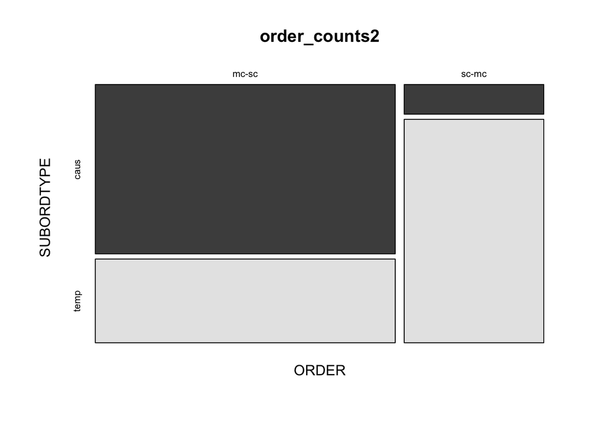

```r
# Works with raw counts and percentages
# Using the output of xtabs() as input
mosaicplot(order_counts2, color = TRUE)
```

**Barplots (raw counts)**

The workhorse of categorical data analysis is the barplot. Base R functions usually require a `table` object as input, whereas `ggplot2` can operate on the raw dataset.

### One variable

**Base R**

- Base R barplot with `barplot()`; requires the counts as computed by `tables()` or `xtabs()`

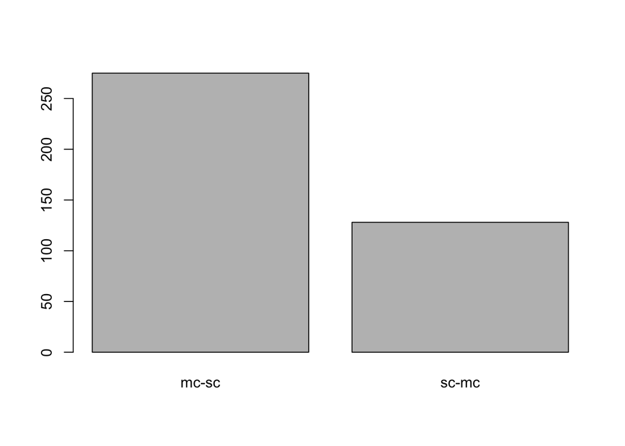

```r
# Generate cross-table
order_freq1 <- table(cl.order$ORDER)

# Create barplot
barplot(order_freq1)
```

**ggplot2**

- Barplot with `geom_bar()` using the raw input data

```r
# Requirement: library(tidyverse)

# Raw input data
head(cl.order)
```

```
# A tibble: 6 × 8
   CASE ORDER SUBORDTYPE LEN_MC LEN_SC LENGTH_DIFF CONJ     MORETHAN2CL
  <dbl> <chr> <chr>       <dbl>  <dbl>       <dbl> <chr>    <chr>
1  4777 sc-mc temp            4     10          -6 als/when no
2  1698 mc-sc temp            7      6           1 als/when no
3   953 sc-mc temp           12      7           5 als/when yes
4  1681 mc-sc temp            6     15          -9 als/when no
5  4055 sc-mc temp            9      5           4 als/when yes
6   967 sc-mc temp            9      5           4 als/when yes
```

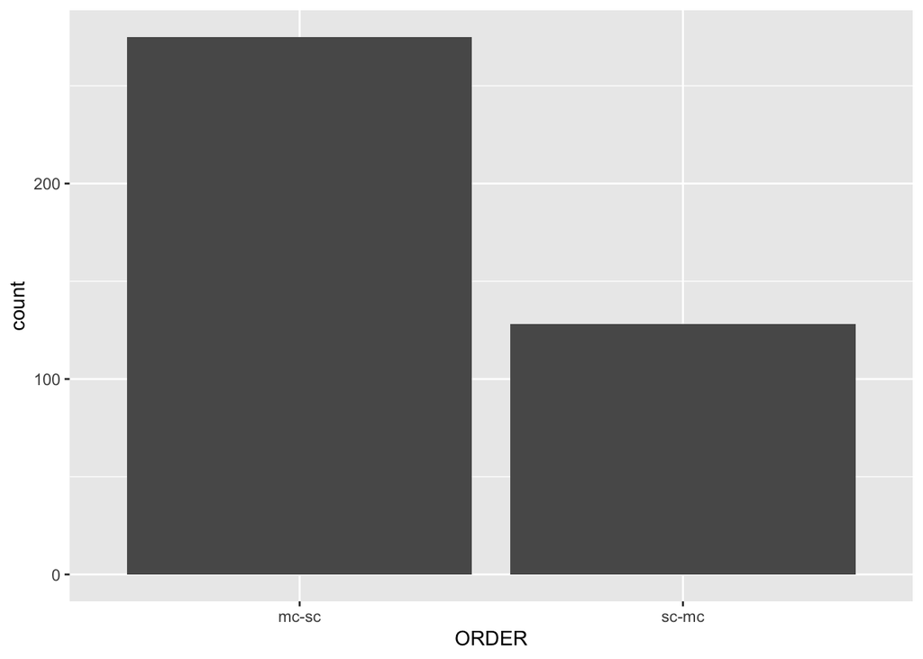

```r
# Create barplot
ggplot(cl.order, aes(x = ORDER)) +
  geom_bar()
```

### Two variables

Bivariate barplots can be obtained by either supplying a contingency table (Base R) or by mapping the second variable onto the `fill` argument using the raw data.

**Base R**

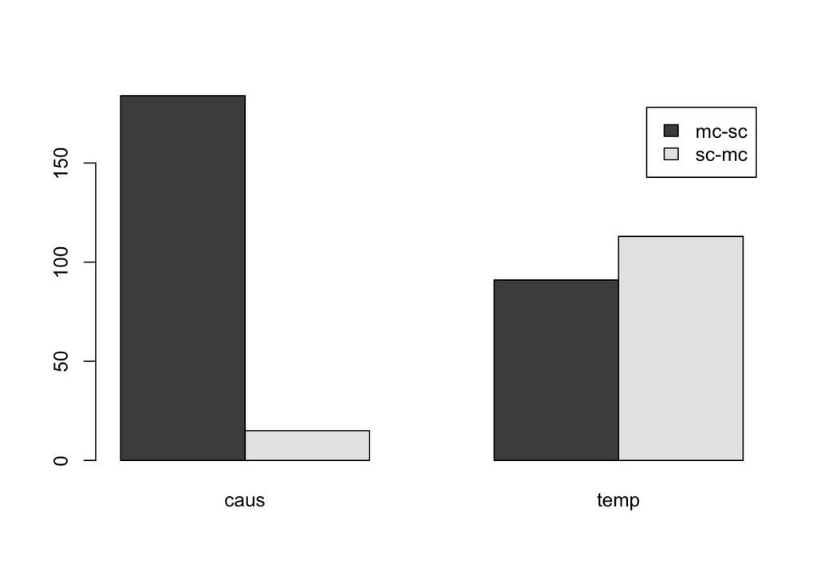

```r
# Generate cross-table with two variables
order_counts2 <- xtabs(~ ORDER + SUBORDTYPE, cl.order)

# Create simple barplot
barplot(order_counts2,
        beside = TRUE,  # Make bars side-by-side
        legend = TRUE)  # Add a legend
```

**Base R (fully customised)**

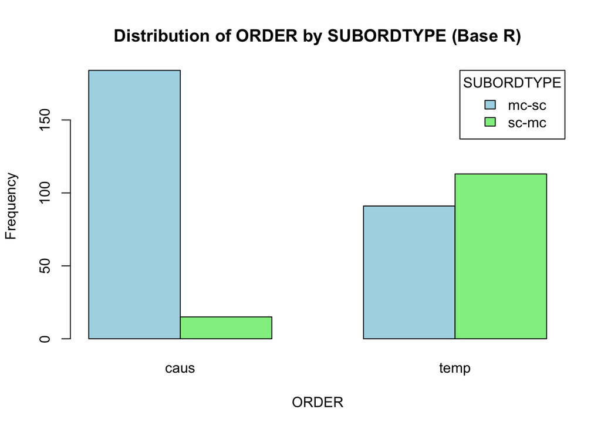

```r
# Generate cross-table with two variables
order_counts2 <- xtabs(~ ORDER + SUBORDTYPE, cl.order)

# Customise barplot with axis labels, colours and legend
barplot(order_counts2,
        beside = TRUE,  # Make bars dodged (i.e., side by side)
        main = "Distribution of ORDER by SUBORDTYPE (Base R)",
        xlab = "ORDER",
        ylab = "Frequency",
        col = c("lightblue", "lightgreen"), # Customize colors
        legend = TRUE,  # Add a legend
        args.legend = list(title = "SUBORDTYPE", x = "topright"))
```

**ggplot2**

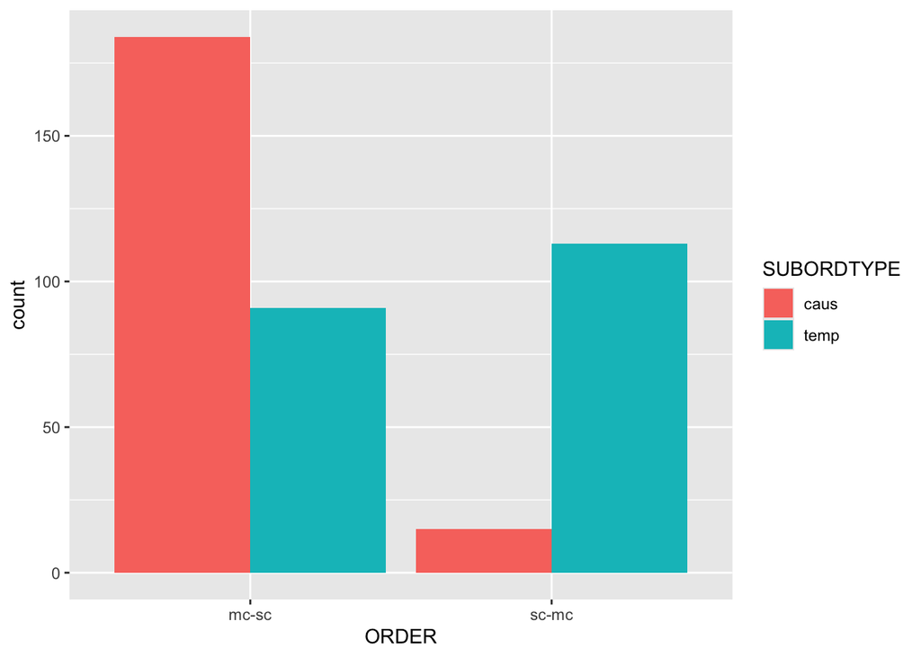

```r
# Requirement: library(tidyverse)

# Create simple barplot with the ggplot() function
ggplot(cl.order, aes(x = ORDER, fill = SUBORDTYPE)) +
  geom_bar(position = "dodge")
```

**ggplot2 (fully customised)**

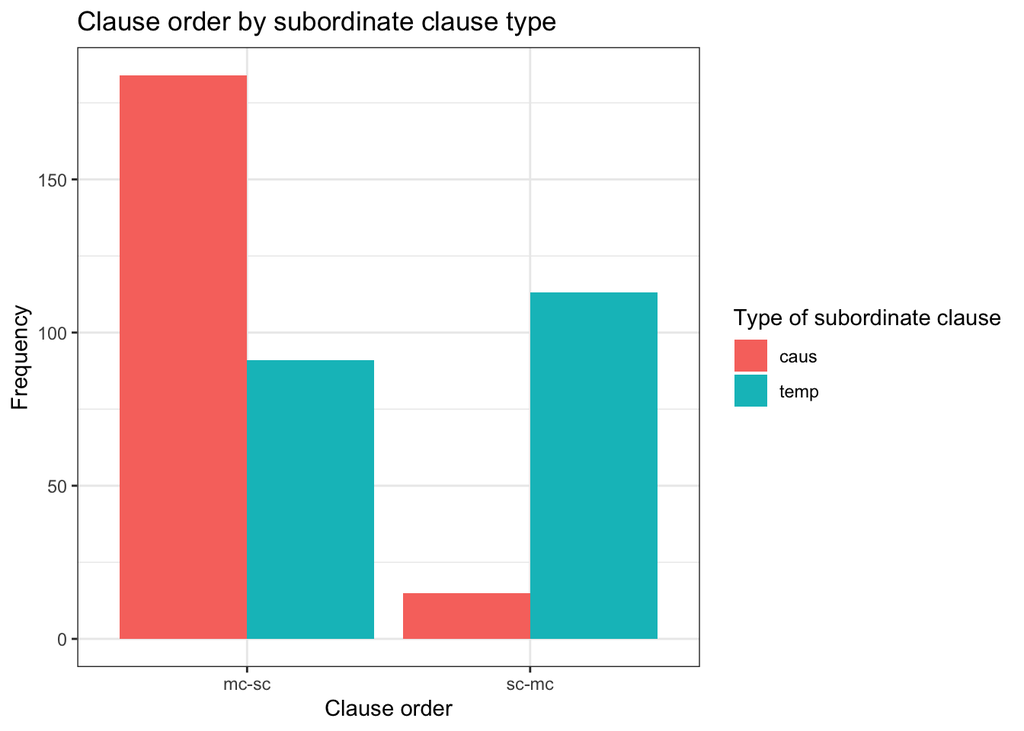

```r
# Requirement: library(tidyverse)

# Fully customised ggplot2 object
ggplot(cl.order, aes(x = ORDER, fill = SUBORDTYPE)) +
  geom_bar(position = "dodge") +
  labs(
    title = "Clause order by subordinate clause type",
    x = "Clause order",
    y = "Frequency",
    fill = "Type of subordinate clause"
  ) +
  theme_bw()
```

**Barplots (percentages)**

**Base R**

In very much the same way as with the raw counts:

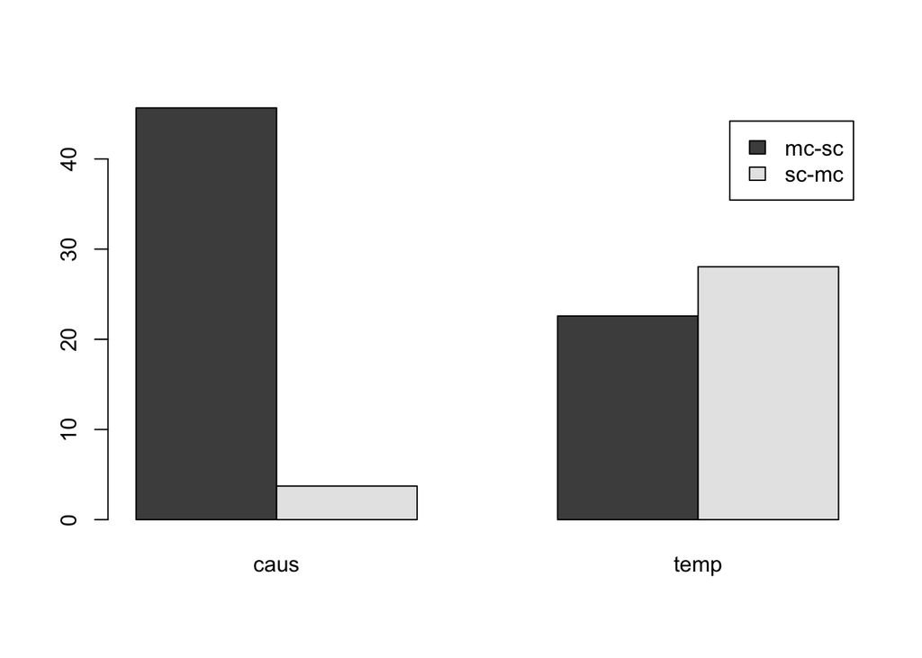

```r
# Create simple barplot with a percentage table as input
barplot(pct1,
        beside = TRUE,  # Make bars side-by-side
        legend = TRUE)  # Add a legend
```

**ggplot2**

Here, a few tweaks are necessary. Because the `ggplot()` function prefers to works with data frames rather than cross-tables, we’ll have to coerce it into one first:

```r
# Convert a percentage table to a data frame
# My recommendation: Use the pct2 object, which was generated using xtabs() because it will keep the variable names
pct2_df <- as.data.frame(pct2)

print(pct2_df)
```

```
  ORDER SUBORDTYPE      Freq
1 mc-sc       caus 45.657568
2 sc-mc       caus  3.722084
3 mc-sc       temp 22.580645
4 sc-mc       temp 28.039702
```

Now we can plot the percentages with `geom_col()`. This geom (= ‘geometric object’) allows us to manually specify what should be mapped onto the y-axis:

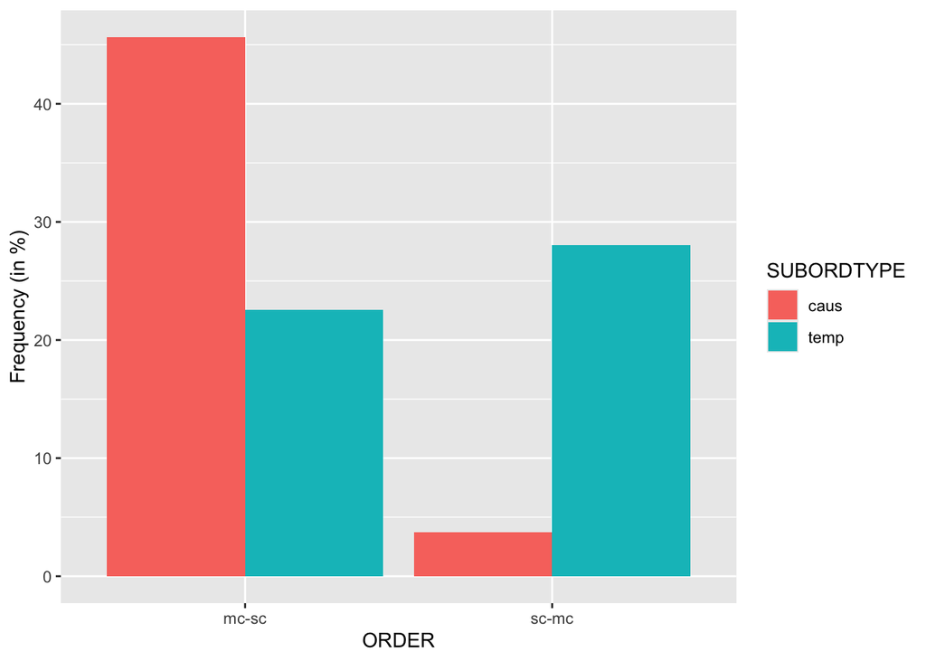

```r
# Requirement: library(tidyverse)

# Create barplot with user-defined y-axis, which requires geom_col() rather than geom_bar()
ggplot(pct2_df, aes(x = ORDER, y = Freq, fill = SUBORDTYPE)) +
  geom_col(position = "dodge") +
  labs(y = "Frequency (in %)")
```

**Bubble plot (percentages)**

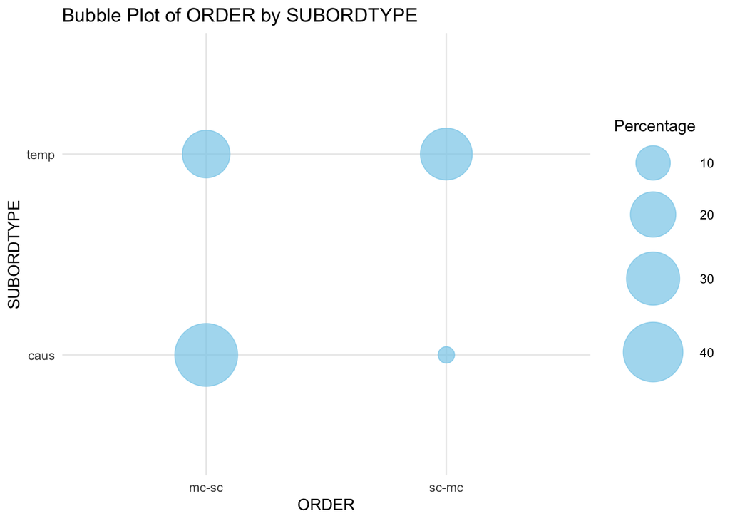

```r
# Requirement: library(tidyverse)

# Bubble plot
ggplot(pct2_df, aes(x = ORDER, y = SUBORDTYPE, size = Freq)) +
  geom_point(color = "skyblue", alpha = 0.7) +
  scale_size_continuous(range = c(5, 20)) +  # Adjust bubble size range
  labs(title = "Bubble Plot of ORDER by SUBORDTYPE",
       x = "ORDER",
       y = "SUBORDTYPE",
       size = "Percentage") +
  theme_minimal()
```

**Alluvial plot (percentages)**

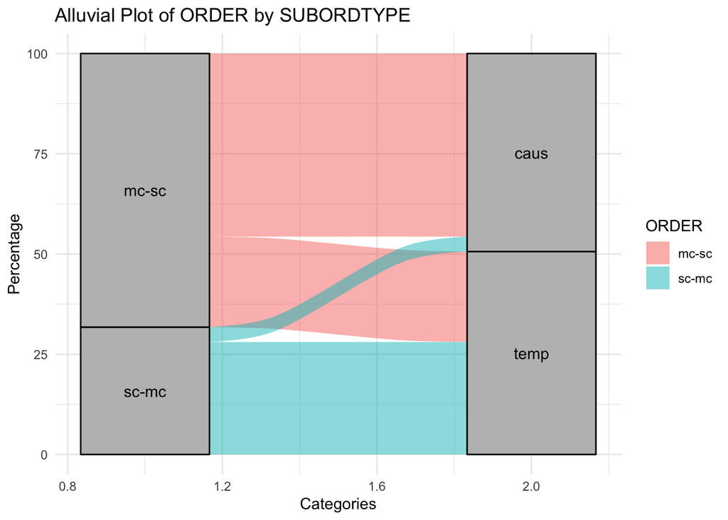

```r
# Make sure to install this library prior to running the code below
library(ggalluvial)

ggplot(pct2_df,
       aes(axis1 = ORDER, axis2 = SUBORDTYPE, y = Freq)) +
  geom_alluvium(aes(fill = ORDER)) +
  geom_stratum(fill = "gray") +
  geom_text(stat = "stratum", aes(label = after_stat(stratum))) +
  labs(title = "Alluvial Plot of ORDER by SUBORDTYPE",
       x = "Categories", y = "Percentage") +
  theme_minimal()
```

## Exporting tables to MS Word

The `crosstable` and `flextable` packages make it very easy to export elegant tables to MS Word.

**Clean and to the point: `crosstable()`**

This is perhaps the most elegant solution. Generate a `crosstable()` object by supplying at the very least …

- the original dataset (`data = cl.order`),
- the dependent variable (`cols = ORDER`), and
- the independent variable (`by = SUBORDTYPE`).

You can further specify …

- whether to include column totals, row totals or both (here: `total = both`),
- the rounding scheme (here: `percent_digits = 2`),
- …

```r
# Required libraries:
# library(crosstable)
# library(flextable)

# Create the cross table
output1 <- crosstable(data = cl.order,
                      cols = ORDER,
                      by = SUBORDTYPE,
                      total = "both",
                      percent_digits = 2)

# Generate file
as_flextable(output1)
```

[output not shown]

**How much info do you need? Yes.**

It also possible to use `as_flextable()` without pre-processing the data with `crosstable()`; supplying a table preferably created with `xtabs()` is sufficient. Without any doubt, the output is extremely informative, yet it is everything but reader-friendly.

For this reason, I recommend relying on the less overwhelming `crosstable()` option above if a plain and easy result is desired. However, readers who would like to leverage the full capabilities of the `flextable()` package and familiarise themselves with the abundant options for customisation, can find the detailed documentation [here](https://ardata-fr.github.io/flextable-book/crosstabs.html#using-tables).

```r
# Requires the following library:
# library(flextable)

# Create a table
tab1 <- xtabs(~ ORDER + SUBORDTYPE, cl.order)

# Directly convert a table to a flextable with as_flextable()
output_1 <- as_flextable(tab1)

# Print output
print(output_1)
```

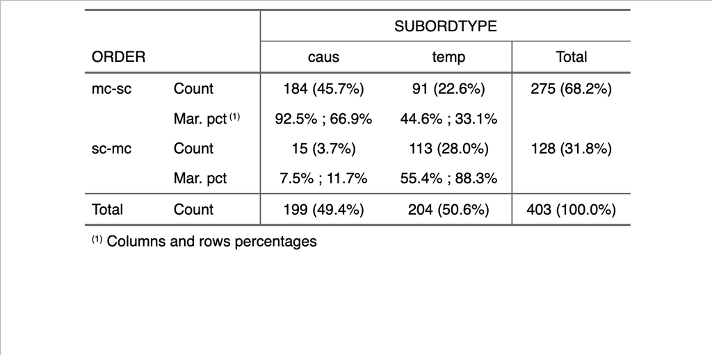

## Workflow exercises

**Solutions**

You can find the solutions to the exercises [here](https://osf.io/s7yj2).

**Exercise 1** Download the dataset `objects.xlsx` from https://osf.io/j2mnx. Load it into R and store it in a variable `objects`. Make sure to load all the necessary libraries.

**Exercise 2** Many rows from are irrelevant for the analysis. Exclude all rows from that are marked as containing passive clauses (see `Clause_voice` column). Store this reduced subset in a new variable `objects_filtered`.

**Exercise 3** Investigate the relationship between

- `Object_realisation` and `Register` as well as
- `Object_realisation` and `Lemma`

by computing frequency tables and percentages based on `objects_filtered`. Plot your results and export your tables and figures to a Microsoft Word document.

**Exercise 4** Which verb has the highest $\frac{\text{null}}{\text{null} + \text{overt}}$ ratio and which one has the lowest?

## References

Paquot, Magali, and Tove Larsson. 2020. “Descriptive Statistics and Visualization with r.” In *A Practical Handbook of Corpus Linguistics*, edited by Magali Paquot and Stefan Thomas Gries, 375–99. Cham: Springer.